# Study Notes for Postgrest Starter Kit

Mert Nuhoglu

2018-02-26T11:48:22+03:00

```r
options(width = 150)
options(max.print = 30)
```

[`postgrest`](https://postgrest.com/) is an alternative to `GrapqQL`. It generates and serves REST APIs from a Postgres database automatically.

[`postgrest starter kit`](https://github.com/subzerocloud/postgrest-starter-kit) is a handy starter kit and tooling to produce production ready applications on top of postgrest.

The official documentations of [`postgrest`](https://postgrest.com/) and [`psk (postgrest starter kit)`](https://github.com/subzerocloud/postgrest-starter-kit/wiki/Home) are very high quality. In this blog post, I follow the tutorial steps already explained in these documents.

## Installation and Setup

```
$ git clone --single-branch https://github.com/subzerocloud/postgrest-starter-kit khumbuicefall
$ cd khumbuicefall
```

Edit `.env`

```
COMPOSE_PROJECT_NAME=khumbuicefall
```

Run the server embedded in docker container:

```
$ docker-compose up -d # wait for 5-10s before running the next command
```

Install and run [subzero-cli] to see what is going inside (optional):

```
$ docker pull subzerocloud/subzero-cli-tools
$ npm install -g subzero-cli
$ subzero dashboard
```

## Basic REST Calls

```
$ curl http://localhost:8080/rest/todos?select=id
[{"id":1},{"id":3},{"id":6}]
```

Make an authorized request

```
$ export JWT_TOKEN=eyJhbGciOiJIUzI1NiIsInR5cCI6IkpXVCJ9.eyJ1c2VyX2lkIjoxLCJyb2xlIjoid2VidXNlciJ9.uSsS2cukBlM6QXe4Y0H90fsdkJSGcle9b7p_kMV1Ymk
$ curl -H "Authorization: Bearer $JWT_TOKEN" http://localhost:8080/rest/todos?select=id,todo
[{"id":1,"todo":"item_1"},{"id":3,"todo":"item_3"},{"id":6,"todo":"item_6"}]
```

## Update Sample Data

Update the initial sample data and check if it is updated in the database:

Edit `db/src/sample_data/data.sql`:

```
1   item_1  FALSE   1
->
1   item_1_updated  FALSE   1
```

Run request again:

```
$ curl -H "Authorization: Bearer $JWT_TOKEN" http://localhost:8080/rest/todos?select=id,todo
[{"id":1,"todo":"item_1_updated"},{"id":3,"todo":"item_3"},{"id":6,"todo":"item_6"}]
```

## Check Generated SQL Using subzero

`subzero` is a monitoring tool. It shows the internal logs of `openresty`, `rabbitmq`, `postgres`, and `postgrest`.

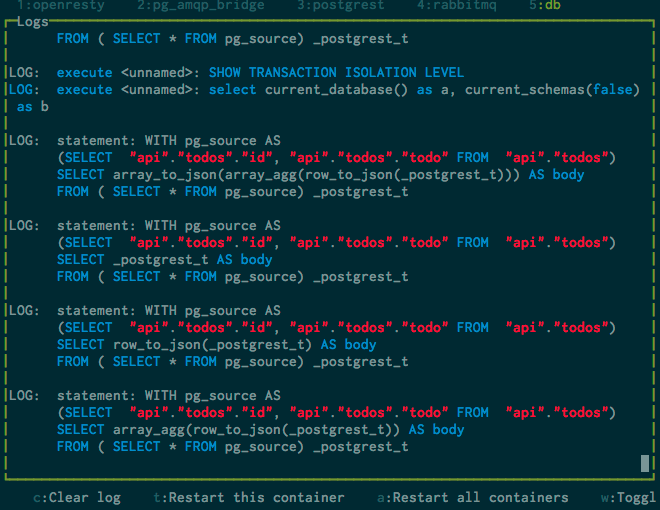

subzero

```
$ curl http://localhost:8080/rest/todos?select=id
```

The following SQL code is generated automatically by `postgrest`:

```sql
WITH pg_source AS
  (SELECT  "api"."todos"."id" FROM  "api"."todos")
  SELECT
    null AS total_result_set, pg_catalog.count(_postgrest_t) AS page_total, array[]::text[] AS header, coalesce(array_to_json(array_agg(row_to_json(_postgrest_t))), '[]')::character varying AS body
    FROM ( SELECT * FROM pg_source) _postgrest_t
```

```
+--------------------+--------------+----------+------------------------------+
| total_result_set   | page_total   | header   | body                         |
|--------------------+--------------+----------+------------------------------|
| <null>             | 3            | []       | [{"id":1},{"id":3},{"id":6}] |
+--------------------+--------------+----------+------------------------------+
```

Let’s return both `id` and `todo` attributes:

```
$ curl -H "Authorization: Bearer $JWT_TOKEN" http://localhost:8080/rest/todos?select=id,todo
```

```sql
WITH pg_source AS
  (SELECT  "api"."todos"."id", "api"."todos"."todo" FROM  "api"."todos")
  SELECT null AS total_result_set, pg_catalog.count(_postgrest_t) AS page_total, array[]::text[] AS header, coalesce(array_to_json(array_agg(row_to_json(_postgrest_t))), '[]')::character varying AS body
  FROM ( SELECT * FROM pg_source) _postgrest_t
```

```
+--------------------+--------------+----------+--------------------------------------------------------------------------------------+
| total_result_set   | page_total   | header   | body                                                                                 |
|--------------------+--------------+----------+--------------------------------------------------------------------------------------|
| <null>             | 3            | []       | [{"id":1,"todo":"item_1_updated"},{"id":3,"todo":"item_3"},{"id":6,"todo":"item_6"}] |
+--------------------+--------------+----------+--------------------------------------------------------------------------------------+
```

In order to understand this code, I simplified it to its core:

```sql
WITH pg_source AS
  (SELECT  "api"."todos"."id", "api"."todos"."todo" FROM  "api"."todos")
  SELECT _postgrest_t AS body
  FROM ( SELECT * FROM pg_source) _postgrest_t
```

```
+--------------------+
| body               |
|--------------------|
| (1,item_1_updated) |
| (3,item_3)         |
| (6,item_6)         |
+--------------------+
```

Adding `row_to_json` function:

```sql
WITH pg_source AS
  (SELECT  "api"."todos"."id", "api"."todos"."todo" FROM  "api"."todos")
  SELECT row_to_json(_postgrest_t) AS body
  FROM ( SELECT * FROM pg_source) _postgrest_t
```

```
+----------------------------------+
| body                             |
|----------------------------------|
| {"id":1,"todo":"item_1_updated"} |
| {"id":3,"todo":"item_3"}         |
| {"id":6,"todo":"item_6"}         |
+----------------------------------+
```

Adding `array_agg` function:

```sql
WITH pg_source AS
  (SELECT  "api"."todos"."id", "api"."todos"."todo" FROM  "api"."todos")
  SELECT array_agg(row_to_json(_postgrest_t)) AS body
  FROM ( SELECT * FROM pg_source) _postgrest_t
```

```
+----------------------------------------------------------------------------------------------+
| body                                                                                         |
|----------------------------------------------------------------------------------------------|
| ['{"id":1,"todo":"item_1_updated"}', '{"id":3,"todo":"item_3"}', '{"id":6,"todo":"item_6"}'] |
+----------------------------------------------------------------------------------------------+
```

Adding `array_to_json` function:

```sql
WITH pg_source AS
  (SELECT  "api"."todos"."id", "api"."todos"."todo" FROM  "api"."todos")
  SELECT array_to_json(array_agg(row_to_json(_postgrest_t))) AS body
  FROM ( SELECT * FROM pg_source) _postgrest_t
```

```
+--------------------------------------------------------------------------------------+
| body                                                                                 |
|--------------------------------------------------------------------------------------|
| [{"id":1,"todo":"item_1_updated"},{"id":3,"todo":"item_3"},{"id":6,"todo":"item_6"}] |
+--------------------------------------------------------------------------------------+
```

`postgrest` returns JSON formatted data by default. It looks like this is done by these three function calls: `array_to_json(array_agg(row_to_json(...)))`

## Check Database Logs

When I make any change in any of the watched `*.sql` files, `psk` automatically detects the change event and reruns all these `*.sql` files from scratch. I can see what is going on from the logs inside `subzero`.

To see the logs clearly, I first ran `c: Clear Log` inside `subzero`. Then, I made an editing inside `db/src/data/todo.sql`. That generated the following logs:

```
 ./db/src/data/todo.sql changed
Starting code reload ------------------------
LOG:  statement: SELECT pg_terminate_backend(pid) FROM pg_stat_activity WHERE datname = 'app';
FATAL:  terminating connection due to administrator command
LOG:  statement: DROP DATABASE if exists app;

LOG:  statement: CREATE DATABASE app;

Ready ---------------------------------------
LOG:  statement: set client_min_messages to warning;
```

`todo.sql` script is imported (or included) from `db/src/data/schema.sql`

```
\ir todo.sql
```

`db/src/data/schema.sql` script is imported from `db/src/init.sql`

```
\ir data/schema.sql
```

The first visible line in `init.sql` is:

```
set client_min_messages to warning;
```

So, it looks like the above log messages after `Ready ----` line come from `init.sql`. Prior statements are somehow handled by `psk` or `postgrest`.

## File Structure of `.sql` Files

`init.sql` file contains several `include` i.e. `\ir` statements such as:

```
\ir data/schema.sql
\ir api/schema.sql
\ir authorization/roles.sql
\ir authorization/privileges.sql
\ir sample_data/data.sql
```

`.sql` files are separated into 4 folders: `data`, `api`, `authorization`, `sample_data`.

`data` folder contains schema definition commands such as `CREATE TABLE`

`api` folder contains view definition commands such as `CREATE VIEW`

`authorization` folder contains role and privilege definition commands such as `CREATE ROLE`

`sample_data` folder contains actual sample data commands such as `INSERT` or `COPY`

General logical structure of calling these `.sql` files is the same. For example, `init.sql` imports `data/schema.sql`. Then `data/schema.sql` file imports all the remaining `.sql` files inside `data/` folder.

## Creating New Table and Sample Data

Create `db/src/data/tables01.sql` and put the `CREATE TABLE` statements inside:

```sql
create table client (
  id           serial primary key,
  name         text not null,
  address      text,
  user_id      int not null references "user"(id),
  created_on   timestamptz not null default now(),
  updated_on   timestamptz
);
create index client_user_id_index on client(user_id);
```

Edit `db/src/data/schema.sql` to import this new file:

```
\ir todo.sql
\ir tables01.sql
```

Now, create `db/src/api/views_and_procedures01.sql` and put `CREATE VIEW` statements inside:

```sql
create or replace view clients as
select id, name, address, created_on, updated_on from data.client;
```

Edit `db/src/api/schema.sql` to import this new file:

```
\ir todos.sql
\ir views_and_procedures01.sql
```

Edit `db/src/sample_data/data.sql` to add the following lines:

```sql
set search_path = data, public;
\echo # filling table client (3)
COPY client (id,name,address,user_id,created_on,updated_on) FROM STDIN (FREEZE ON);
1   Apple   address_1_  1   2017-07-18 11:31:12 \N
2   Microsoft   address_1_  1   2017-07-18 11:31:12 \N
3   Amazon  address_1_  2   2017-07-18 11:31:12 \N
\.
--
ALTER SEQUENCE client_id_seq RESTART WITH 4;
--
ANALYZE client;
```

Edit `db/src/sample_data/reset.sql` and add this line before `COMMIT`:

```
truncate data.client restart identity cascade;
```

Now, after saving all these files, `init.sql` is automatically called by `psk` and all the new tables, views, and sample data are created. Check in `psql`:

```
app=# set search_path = data, public;
SET
app=# \dt
          List of relations
 Schema |  Name  | Type  |   Owner
--------+--------+-------+-----------
 data   | client | table | superuser
 data   | todo   | table | superuser
 data   | user   | table | superuser
(3 rows)
```

Edit `db/src/authorization/privileges.sql` and add `GRANT` privilege statements:

```sql
grant select, insert, update, delete
on api.clients
to webuser;
```

Note that, `api.clients` refers to the view `api.clients` not to the table `data.client`.

Now, make a REST API call:

```bash
$ curl -H "Authorization: Bearer $JWT_TOKEN" http://localhost:8080/rest/clients?select=id,name
[{"id":1,"name":"Apple"},{"id":2,"name":"Microsoft"},{"id":3,"name":"Amazon"}]
```

In this section, I defined only one table `client`. The actual tutorial creates additional tables such as `project`, `task` etc.

## Summary of Steps

1. basic REST request

   ```
   $ curl http://localhost:8080/rest/todos?select=id
   [{"id":1},{"id":3},{"id":6}]
   ```

2. authorized REST request

   ```
   $ export JWT_TOKEN=eyJhbGciOiJIUzI1NiIsInR5cCI6IkpXVCJ9.eyJ1c2VyX2lkIjoxLCJyb2xlIjoid2VidXNlciJ9.uSsS2cukBlM6QXe4Y0H90fsdkJSGcle9b7p_kMV1Ymk
   $ curl -H "Authorization: Bearer $JWT_TOKEN" http://localhost:8080/rest/todos?select=id,todo
   [{"id":1,"todo":"item_1"},{"id":3,"todo":"item_3"},{"id":6,"todo":"item_6"}]
   ```

3. Edit `db/src/sample_data/data.sql`:

   ```
   $ curl -H "Authorization: Bearer $JWT_TOKEN" http://localhost:8080/rest/todos?select=id,todo
   [{"id":1,"todo":"item_1_updated"},{"id":3,"todo":"item_3"},{"id":6,"todo":"item_6"}]
   ```

4. Create new table: data/table.sql imported from data/schema.sql
5. Create new view as API: api/views_and_procedures.sql imported from api/schema.sql
6. Create sample data: sample_data/data.sql imported from reset.sql

   delete previous data in reset.sql:

   ```
   truncate data.client restart identity cascade;
   ```

7. Grant privilege for the new view: authorization/privileges.sql imported from init.sql
8. Make request to new API:

   ```
   $ curl -H "Authorization: Bearer $JWT_TOKEN" http://localhost:8080/rest/clients?select=id,name
   ```